# Face_Segmentation_Assignment

```python
# Import the necessary libraries.
```

```python
! pip install tensorflow-gpu
! pip install opencv-python
```

```python
! pip install tensorflow-addons
```

```python
import numpy as np
import pandas as pd
import matplotlib.pyplot as plt
%matplotlib inline
import seaborn as sns
```

```python
import cv2
import matplotlib.patches as patches
```

```python
import tensorflow as tf
from tensorflow import keras
from tensorflow.keras import layers
from tensorflow.keras.applications.mobilenet import preprocess_input
import tensorflow_addons as tfa
tf.__version__
```

```
'2.3.1'
```

### Mount Google drive if you are using google colab

- We recommend using Google Colab as you can face memory issues and longer runtimes while running on local

```python
from google.colab import drive
drive.mount('/content/drive')
```

### Load the "images.npy" file (2 marks)

- This file contains images with details of bounding boxes

```python
file_name='/content/drive/My Drive/images.npy'
dataset = np.load(file_name,allow_pickle=True)
```

### Check one sample from the loaded "images.npy" file (3 marks)

- Hint: print data[10][1]

```python
plt.imshow(dataset[10][0])
```

[output not shown]

[figure not shown]

```python
def display_bounding_box(image,all_points_info):
  fig,ax = plt.subplots(1)
  for k in all_points_info:
    image_height,image_width=k['imageHeight'],k['imageWidth']
    corner_point_1_x,corner_point_1_y=k['points'][0]['x'],k['points'][0]['y']
    corner_point_2_x,corner_point_2_y=k['points'][1]['x'],k['points'][1]['y']
    image_height,image_width,corner_point_1_x,corner_point_1_y,corner_point_2_x,corner_point_2_y
    corner_set_1=(int(corner_point_1_x*image_width),int(corner_point_1_y*image_height))
    corner_set_2=(int(corner_point_2_x*image_width),int(corner_point_2_y*image_height))
    rect = patches.Rectangle(corner_set_1, corner_set_2[0]-corner_set_1[0], corner_set_2[1]-corner_set_1[1], linewidth=2, edgecolor='b', facecolor='none')
    ax.add_patch(rect)
  ax.imshow(image)
  # plt.show()
index_to_display=10
display_bounding_box(dataset[index_to_display][0],dataset[index_to_display][1])
```

```python
dataset[10][1]
```

```
[{'imageHeight': 337,
  'imageWidth': 600,
  'label': ['Face'],
  'notes': '',
  'points': [{'x': 0.48, 'y': 0.10385756676557864},
   {'x': 0.7716666666666666, 'y': 0.6795252225519288}]}]
```

### Set image dimensions (2 marks)

- Initialize image height, image width with value: 224

```python
IMAGE_SIZE=224
IMAGE_HEIGHT, IMAGE_WIDTH = IMAGE_SIZE, IMAGE_SIZE
HEIGHT_CELLS = 28
WIDTH_CELLS = 28
```

[figure not shown]

```python
# Resizing Images and Corresponding Labels
def resizing_images(image,all_points_info,IMAGE_SIZE=128):
  # fig,ax = plt.subplots(1)
  new_image=cv2.resize(image,(IMAGE_SIZE,IMAGE_SIZE))
  faces=[]
  for k in all_points_info:
    image_height,image_width=k['imageHeight'],k['imageWidth']
    corner_point_1_x,corner_point_1_y=k['points'][0]['x'],k['points'][0]['y']
    corner_point_2_x,corner_point_2_y=k['points'][1]['x'],k['points'][1]['y']
    image_height,image_width,corner_point_1_x,corner_point_1_y,corner_point_2_x,corner_point_2_y
    corner_set_1=(corner_point_1_x,corner_point_1_y)
    corner_set_2=(corner_point_2_x,corner_point_2_y)
    temp={
    'imageWidth':IMAGE_SIZE,
    'imageHeight':IMAGE_SIZE,
    'label':['Face'],
    'notes':'',
    'points':[{'x':corner_set_1[0],'y':corner_set_1[1]},{'x':corner_set_2[0],'y':corner_set_2[1]}]}
    faces.append(temp)
  # ax.imshow(new_image)
  # display_bounding_box(new_image,faces)
  return new_image
index_to_display=10
plt.imshow((resizing_images(dataset[index_to_display][0],dataset[index_to_display][1],IMAGE_SIZE)))
```

```python
# Removing Additional Channels from Images...........
```

```python
dataset_modified=[]
for i in range(0,len(dataset)):
  if (len(cv2.split(dataset[i][0]))) == 3:
    b_channel, g_channel, r_channel = cv2.split(dataset[i][0])
    img_RGB = cv2.merge((b_channel, g_channel, r_channel))
    # plt.imshow(img_RGB)
    dataset_modified.append(img_RGB)
  elif (len(cv2.split(dataset[i][0]))) == 4:
    b_channel, g_channel, r_channel , a_channel = cv2.split(dataset[i][0])
    img_RGB = cv2.merge((b_channel, g_channel, r_channel))
    # plt.imshow(img_RGB)
    dataset_modified.append(img_RGB)
  elif (len(cv2.split(dataset[i][0]))) == 1:
    gray_channel = np.array(cv2.split(dataset[i][0]))
    gray_channel=gray_channel.reshape(gray_channel.shape[1],gray_channel.shape[2])
    img_RGB = cv2.merge((gray_channel,gray_channel,gray_channel))
    # plt.imshow(img_RGB)
    dataset_modified.append(img_RGB)
  else:
    continue
```

### Create features and labels

- Here feature is the image
- The label is the mask
- Images will be stored in "X" array
- Masks will be stored in "masks" array

```python
# # (len(cv2.split(dataset[272][0])))
# gray_channel = np.array(cv2.split(dataset[272][0]))
# print(gray_channel.shape)
# gray_channel=gray_channel.reshape(gray_channel.shape[1],gray_channel.shape[2])
# print(gray_channel.shape)
# # img_RGB = cv2.merge((gray_channel,gray_channel,gray_channel))
# # dataset_modified.append(img_RGB)
# plt.imshow(dataset[272][0])
```

```python
def creating_masks(data,IMAGE_HEIGHT,IMAGE_WIDTH):
  masks = np.zeros((int(data.shape[0]), IMAGE_HEIGHT, IMAGE_WIDTH))
  X = np.zeros((int(data.shape[0]), IMAGE_HEIGHT, IMAGE_WIDTH, 3))
  for index in range(data.shape[0]):
      img = data[index][0]
      img = cv2.resize(img, dsize=(IMAGE_HEIGHT, IMAGE_WIDTH), interpolation=cv2.INTER_CUBIC)
      try:
        img = img[:, :, :3]
      except:
        continue
      X[index] = preprocess_input(np.array(img, dtype=np.float32))
      for i in data[index][1]:
          x1 = int(i["points"][0]['x'] * IMAGE_WIDTH)
          x2 = int(i["points"][1]['x'] * IMAGE_WIDTH)
          y1 = int(i["points"][0]['y'] * IMAGE_HEIGHT)
          y2 = int(i["points"][1]['y'] * IMAGE_HEIGHT)
          masks[index][y1:y2, x1:x2] = 1
  return masks
masks=creating_masks(dataset,IMAGE_SIZE,IMAGE_SIZE)
```

[figure not shown]

```python
index_to_display=10
fig,ax=plt.subplots(2)
ax[0].imshow(dataset[index_to_display][0])
ax[1].imshow(masks[index_to_display])
```

### Split the data into training and testing (3 marks)

- 400 images in training
- 9 images in testing data

```python
from sklearn import model_selection
dataset_x=[]
dataset_y=[]
for i in range(0,len(dataset_modified)):
  dataset_x.append(preprocess_input(np.array(cv2.resize(dataset_modified[i],(IMAGE_SIZE,IMAGE_SIZE),interpolation=cv2.INTER_CUBIC),dtype=np.float32)))
  dataset_y.append(cv2.resize(masks[i],(HEIGHT_CELLS,WIDTH_CELLS),interpolation=cv2.INTER_NEAREST))
x_train,x_test,y_train,y_test=model_selection.train_test_split(np.array(dataset_x),np.array(dataset_y),random_state=0,test_size=0.02)
```

### Print a sample training image, image array and its mask (3 marks)

```
Clipping input data to the valid range for imshow with RGB data ([0..1] for floats or [0..255] for integers).
```

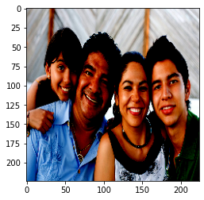

```python
plt.imshow(x_train[0])
```

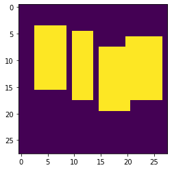

```python
plt.imshow(y_train[0])
```

```python
x_train[0]
```

```
array([[[ 0.56078434,  0.6       ,  0.62352943],
        [ 0.5921569 ,  0.5921569 ,  0.62352943],
        [ 0.60784316,  0.6156863 ,  0.64705884],
        ...,
        [ 0.8509804 ,  0.85882354,  0.8901961 ],
        [ 0.8666667 ,  0.8745098 ,  0.90588236],
        [ 0.85882354,  0.8666667 ,  0.8980392 ]],

       [[ 0.5764706 ,  0.58431375,  0.6156863 ],
        [ 0.60784316,  0.6156863 ,  0.64705884],
        [ 0.6156863 ,  0.62352943,  0.654902  ],
        ...,
        [ 0.8745098 ,  0.88235295,  0.9137255 ],
        [ 0.85882354,  0.8666667 ,  0.8980392 ],
        [ 0.8745098 ,  0.88235295,  0.9137255 ]],

       [[ 0.5764706 ,  0.5764706 ,  0.60784316],
        [ 0.6       ,  0.60784316,  0.6392157 ],
        [ 0.6156863 ,  0.6156863 ,  0.6313726 ],
        ...,
        [ 0.8901961 ,  0.8980392 ,  0.9137255 ],
        [ 0.8745098 ,  0.88235295,  0.90588236],
        [ 0.84313726,  0.8509804 ,  0.8745098 ]],

       ...,

       [[ 0.23921573,  0.49803925,  0.78039217],
        [ 0.19215691,  0.47450984,  0.75686276],
        [ 0.11372554,  0.41176474,  0.7019608 ],
        ...,
        [-0.8352941 , -0.02745098, -0.6156863 ],
        [-0.827451  , -0.01176471, -0.62352943],
        [-0.8039216 ,  0.00392163, -0.6156863 ]],

       [[ 0.20000005,  0.47450984,  0.7490196 ],
        [ 0.16078436,  0.45098042,  0.73333335],
        [ 0.09803927,  0.39607847,  0.6862745 ],
        ...,
        [-0.8039216 , -0.00392157, -0.58431375],
        [-0.8745098 , -0.04313725, -0.6627451 ],
        [-0.8039216 ,  0.00392163, -0.60784316]],

       [[ 0.19215691,  0.4666667 ,  0.73333335],
        [ 0.15294123,  0.43529415,  0.7176471 ],
        [ 0.082353  ,  0.3803922 ,  0.67058825],
        ...,
        [-0.8666667 , -0.03529412, -0.64705884],
        [-0.8117647 ,  0.00392163, -0.60784316],
        [-0.7490196 ,  0.03529418, -0.5764706 ]]], dtype=float32)
```

## Create the model (7 marks)

- Add MobileNet as model with below parameter values
  - input_shape: IMAGE_HEIGHT, IMAGE_WIDTH, 3
  - include_top: False
  - alpha: 1.0
  - weights: "imagenet"
- Add UNET architecture layers
  - This is the trickiest part of the project, you need to research and implement it correctly

```python
from tensorflow.keras.applications.mobilenet import MobileNet
from tensorflow.keras.layers import Reshape, UpSampling2D, Concatenate, Conv2D
from tensorflow.keras.models import Model

def create_model(trainable=True):
    model = MobileNet(input_shape=(IMAGE_HEIGHT, IMAGE_WIDTH, 3), include_top=False, alpha=1.0, weights="imagenet")
    for layer in model.layers:
        layer.trainable = trainable

    block1 = model.get_layer("conv_pw_5_relu").output
    block2 = model.get_layer("conv_pw_11_relu").output
    block3 = model.get_layer("conv_pw_13_relu").output
    block4 = model.get_layer("conv_pw_1_relu").output

    x = Concatenate()([UpSampling2D()(block3), block2])
    x = Concatenate()([UpSampling2D()(x), block1])

    x = Conv2D(1, kernel_size=1, activation="sigmoid")(x)
    x = Reshape((HEIGHT_CELLS, WIDTH_CELLS))(x)

    return Model(inputs=model.input, outputs=x)
```

### Call the create_model function (2 marks)

- Give trainable=False as argument, if you want to freeze lower layers for fast training (but low accuracy)

```python
model = create_model(False)
```

### Print model summary (2 marks)

```python
model.summary()
```

```
Model: "functional_1"
__________________________________________________________________________________________________
Layer (type)                    Output Shape         Param #     Connected to
==================================================================================================
input_1 (InputLayer)            [(None, 224, 224, 3) 0
__________________________________________________________________________________________________
conv1_pad (ZeroPadding2D)       (None, 225, 225, 3)  0           input_1[0][0]
__________________________________________________________________________________________________
conv1 (Conv2D)                  (None, 112, 112, 32) 864         conv1_pad[0][0]
__________________________________________________________________________________________________
conv1_bn (BatchNormalization)   (None, 112, 112, 32) 128         conv1[0][0]
__________________________________________________________________________________________________
conv1_relu (ReLU)               (None, 112, 112, 32) 0           conv1_bn[0][0]
__________________________________________________________________________________________________
conv_dw_1 (DepthwiseConv2D)     (None, 112, 112, 32) 288         conv1_relu[0][0]
__________________________________________________________________________________________________
conv_dw_1_bn (BatchNormalizatio (None, 112, 112, 32) 128         conv_dw_1[0][0]
__________________________________________________________________________________________________
conv_dw_1_relu (ReLU)           (None, 112, 112, 32) 0           conv_dw_1_bn[0][0]
__________________________________________________________________________________________________
conv_pw_1 (Conv2D)              (None, 112, 112, 64) 2048        conv_dw_1_relu[0][0]
__________________________________________________________________________________________________
conv_pw_1_bn (BatchNormalizatio (None, 112, 112, 64) 256         conv_pw_1[0][0]
__________________________________________________________________________________________________
conv_pw_1_relu (ReLU)           (None, 112, 112, 64) 0           conv_pw_1_bn[0][0]
__________________________________________________________________________________________________
conv_pad_2 (ZeroPadding2D)      (None, 113, 113, 64) 0           conv_pw_1_relu[0][0]
__________________________________________________________________________________________________
conv_dw_2 (DepthwiseConv2D)     (None, 56, 56, 64)   576         conv_pad_2[0][0]
__________________________________________________________________________________________________
conv_dw_2_bn (BatchNormalizatio (None, 56, 56, 64)   256         conv_dw_2[0][0]
__________________________________________________________________________________________________
conv_dw_2_relu (ReLU)           (None, 56, 56, 64)   0           conv_dw_2_bn[0][0]
__________________________________________________________________________________________________
conv_pw_2 (Conv2D)              (None, 56, 56, 128)  8192        conv_dw_2_relu[0][0]
__________________________________________________________________________________________________
conv_pw_2_bn (BatchNormalizatio (None, 56, 56, 128)  512         conv_pw_2[0][0]
__________________________________________________________________________________________________
conv_pw_2_relu (ReLU)           (None, 56, 56, 128)  0           conv_pw_2_bn[0][0]
__________________________________________________________________________________________________
```

[output cut: 141 more lines]

```
                                                                 conv_pw_11_relu[0][0]
__________________________________________________________________________________________________
up_sampling2d_1 (UpSampling2D)  (None, 28, 28, 1536) 0           concatenate[0][0]
__________________________________________________________________________________________________
concatenate_1 (Concatenate)     (None, 28, 28, 1792) 0           up_sampling2d_1[0][0]
                                                                 conv_pw_5_relu[0][0]
__________________________________________________________________________________________________
conv2d (Conv2D)                 (None, 28, 28, 1)    1793        concatenate_1[0][0]
__________________________________________________________________________________________________
reshape (Reshape)               (None, 28, 28)       0           conv2d[0][0]
==================================================================================================
Total params: 3,230,657
Trainable params: 1,793
Non-trainable params: 3,228,864
__________________________________________________________________________________________________
```

### Define dice coefficient function (3 marks)

- Create a function to calculate dice coefficient

```python
def dice_coefficient(y_true, y_pred):
    numerator = 2 * tf.reduce_sum(y_true * y_pred)
    denominator = tf.reduce_sum(y_true + y_pred)
    return numerator / (denominator + tf.keras.backend.epsilon())
```

### Define loss function (3 marks)

```python
def loss(y_true, y_pred):
    return binary_crossentropy(y_true, y_pred)- tf.keras.backend.log(dice_coefficient(y_true, y_pred) + tf.keras.backend.epsilon())
```

### Compile the model (3 marks)

- Complie the model using below parameters
  - loss: use the loss function defined above
  - optimizers: use Adam optimizer
  - metrics: use dice_coefficient function defined above

```python
from tensorflow.keras.optimizers import Adam
from tensorflow.keras.losses import binary_crossentropy

optimizer = Adam(lr=1e-2, beta_1=0.9, beta_2=0.999, epsilon=None, decay=0.0, amsgrad=False)
model.compile(loss=loss, optimizer=optimizer, metrics=[dice_coefficient])
```

### Define callbacks (3 marks)

- Use ModelCheckpoint
- Use EarlyStopping
- Use ReduceLROnPlateau

```python
from tensorflow.keras.callbacks import ModelCheckpoint, EarlyStopping, ReduceLROnPlateau
checkpoint = ModelCheckpoint("model-{val_loss:.2f}.h5", monitor="val_loss", verbose=1, save_best_only=True, save_weights_only=True)
stop = EarlyStopping(monitor="val_loss", patience=5)
reduce_lr = ReduceLROnPlateau(monitor="val_loss", factor=0.2, patience=5, min_lr=1e-6, verbose=1)
callbacks=[checkpoint,stop,reduce_lr]
```

### Fit the model (3 marks)

```python
# Observation:-
# By using callbacks the accuracy was decreasing sharply, therefore we avoided the use of callbacks to push accuracy and increase dice coefficient value....................
```

```python
model.fit(x_train, y_train, validation_data = (x_test, y_test), epochs=1000, batch_size=32, verbose=1)
```

```
<tensorflow.python.keras.callbacks.History at 0x7f238c3dfe80>
```

```python
y_test_mask=[]
for i in range(0,len(y_test)):
  image = cv2.resize(x_test[i], (IMAGE_WIDTH, IMAGE_HEIGHT))
  y_test_mask.append(1.0*(model.predict(x=np.array([image]))[0] > 0.5))
y_test_mask=np.array(y_test_mask)
```

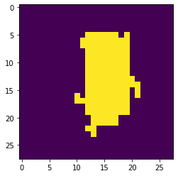

```python
image = cv2.resize(x_test[0], (IMAGE_WIDTH, IMAGE_HEIGHT))
plt.imshow(1.0*(model.predict(x=np.array([image]))[0] > 0.5))
```

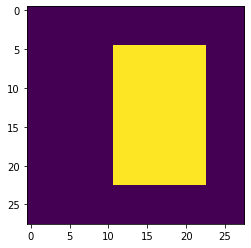

```python
plt.imshow(y_test[0])
```

### Impose the mask on the test image (3 marks)

- In imshow use the alpha parameter and set it to greater than 0.5

```
Clipping input data to the valid range for imshow with RGB data ([0..1] for floats or [0..255] for integers).
```

[figure not shown]

```python
plt.imshow(x_test[0])
```

```
Clipping input data to the valid range for imshow with RGB data ([0..1] for floats or [0..255] for integers).
```

[figure not shown]

```python
image = cv2.resize(x_test[0], (IMAGE_WIDTH, IMAGE_HEIGHT))
pred_mask = cv2.resize(1.0*(model.predict(x=np.array([image]))[0] > 0.5), (IMAGE_WIDTH,IMAGE_HEIGHT))
image2 = image
image2[:,:,0] = pred_mask*image[:,:,0]
image2[:,:,1] = pred_mask*image[:,:,1]
image2[:,:,2] = pred_mask*image[:,:,2]
out_image = image2
plt.imshow(out_image)
```

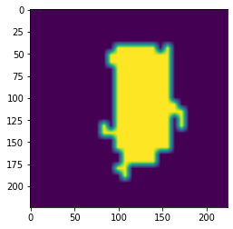

```python
plt.imshow(pred_mask)
```

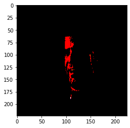

```python
image3 = cv2.resize(image2, dsize=(IMAGE_HEIGHT, IMAGE_WIDTH), interpolation=cv2.INTER_CUBIC)
for i in range(0,3):
  for j in range(0,(IMAGE_HEIGHT)):
    for k in range(0,(IMAGE_WIDTH)):
      if image3[:,:,i][j][k] > 0.5:
        image3[:,:,i][j][k]=1
      else:
        image3[:,:,i][j][k]=0
plt.imshow(image3)
```

### Additional Code Created

- Unusable Code

```python
# def create_segmentation_mask(image,all_points_info):
#   fig,ax = plt.subplots(1)
#   ax.imshow(image)
#   gray_scale_image= cv2.cvtColor(image, cv2.COLOR_BGR2GRAY)
#   new_image=np.zeros(shape=gray_scale_image.shape)
#   # ax.imshow(gray_scale_image)
#   threshold=image.mean()
#   for k in all_points_info:
#     image_height,image_width=k['imageHeight'],k['imageWidth']
#     corner_point_1_x,corner_point_1_y=k['points'][0]['x'],k['points'][0]['y']
#     corner_point_2_x,corner_point_2_y=k['points'][1]['x'],k['points'][1]['y']
#     image_height,image_width,corner_point_1_x,corner_point_1_y,corner_point_2_x,corner_point_2_y
#     corner_set_1=(int(corner_point_1_x*image_width),int(corner_point_1_y*image_height))
#     corner_set_2=(int(corner_point_2_x*image_width),int(corner_point_2_y*image_height))
#   for i in range(0,len(gray_scale_image)):
#     for j in range(0,len(gray_scale_image[i])):
#       if gray_scale_image[i][j]>=threshold:
#         new_image[i][j]=1
#       else:
#         continue
#   ax.imshow(new_image)
#   return new_image
# index_to_display=1
# create_segmentation_mask(dataset[index_to_display][0],dataset[index_to_display][1])
# display_bounding_box(create_segmentation_mask(dataset[index_to_display][0],dataset[index_to_display][1]),dataset[index_to_display][1])
```

```python
# for k in dataset[i][1]:
#     corner_point_1_x,corner_point_1_y=k['points'][0]['x'],k['points'][0]['y']
#     corner_point_2_x,corner_point_2_y=k['points'][1]['x'],k['points'][1]['y']
#     dataset_x.append(np.array((cv2.resize(dataset[i][0],(IMAGE_SIZE,IMAGE_SIZE)))))
#     dataset_y.append(np.array([corner_point_1_x,corner_point_1_y,corner_point_2_x,corner_point_2_y])*IMAGE_SIZE)
# dataset_y=np.array(dataset_y)
```

```python
# index_to_display=10
# fig,ax=plt.subplots(1)
# ax.imshow(x_train[index_to_display])
# rect = patches.Rectangle(((y_train[index_to_display][0]),(y_train[index_to_display][1])), (y_train[index_to_display][2]-y_train[index_to_display][0]), (y_train[index_to_display][3]-y_train[index_to_display][1]), linewidth=2, edgecolor='b', facecolor='none')
# ax.add_patch(rect)
# ax.imshow(x_train[index_to_display])
```